# risk_analysis

### Z-Score Tabanlı Maliyet-Duyarlı Anomali Tespiti: Ülke ve Sektör Bazlı Risk Analizi

Bu çalışmada, sentetik veri üzerinden sektör ve ülke bazlı risk analizi yaparak, anomali tespiti sürecini anlamak ve uygulamak istedim. Veriyi, her biri farklı ülke ve sektöre ait altı merchant’ın günlük işlemlerinden türettim. Her merchant için risk değeri, trend, gürültü ve ani sıçramalar (spike) ekledim. Bu sayede modelin gerçek dünyadaki davranışı simüle etmeye çalıştım.

Analiz süreci şu adımlardan oluşmaktadır:

1. **Veri Üretimi:** Her ülke ve sektör için temel risk düzeyleri tanımlanması ve seçili günlerde sahte anomalilerin eklenmesi
2. **Trend Fit & Z-score Hesabı:** Her merchant’ın risk eğrisine 2. dereceden polinom fit uygulanması ve sapmaların `z` skorları ile standardize edilmesi
3. **Anomali Görselleştirmeleri:** Ülke ve sektör bazında risk trendleri, anomaliler ve residual dağılımları incelenmesi
4. **Model Değerlendirmesi:** $R^2$ skorları, maliyet-duyarlı eşik seçimi (FP/FN cost analizi) ve ROC-AUC ölçütleriyle performans ölçümü
5. **Eşik Optimizasyonu:** Her sektör için en uygun z-threshold değerinin belirlenmesi
6. **Etkisel Analiz:** Tespit edilen anomalilerin, `tx_count`, `refund_rate`, `chargeback_rate` gibi işsel metriklere etkisi % farklarla özetlenmesi

Sonuç olarak, bu notebook dosyası **anomali tespiti için z-skor tabanlı, maliyet-duyarlı ve açıklanabilir bir yaklaşımı** uçtan uca göstermektedir.

```python
import numpy as np
import pandas as pd
from IPython.display import display, Markdown
import matplotlib.pyplot as plt
import matplotlib.colors as mcolors
from sklearn.metrics import r2_score, confusion_matrix, roc_auc_score, average_precision_score
```

İlk olarak farklı ülke ve sektörlerdeki merchant’lar için 120 günlük sentetik işlem verisi ürettim. Amacım temel risk trendi, rastgele gürültü ve anlık “spike” olaylarını bir araya getirerek anomali tespiti için gerçekçi bir veri kümesi oluşturmaktı. Burada:

- Her merchant için ülke ve sektöre göre bir risk trendi oluşturuluyor.
- Rastgele seçilen 3 günde spike etkisi eklenerek olağan dışı artışlar simüle ediliyor.
- Noise eklenerek veri daha gerçekçi hale getiriliyor.
- İşlem hacmi, sepet tutarı, iade ve chargeback oranları gibi gözlem metrikleri üretiliyor.
- Spike günlerinde bu metrikler orantılı olarak artırılıyor.
- Son olarak her gün için toplam risk skoru, gerçek anomali etiketi ve spike şiddeti hesaplanıyor.
- Tüm merchant verileri birleştirilerek tek bir dataframe oluşturuluyor.

| Sütun | Açıklama |
| --- | --- |
| `merchant_id` | Merchant kimliği |
| `country` | Ülke |
| `industry` | Sektör |
| `day` | Gün (0–119) |
| `tx_count` | Günlük işlem sayısı |
| `avg_basket` | Ortalama sepet tutarı |
| `refund_rate` | İade oranı |
| `chargeback_rate` | Chargeback oranı |
| `night_ratio` | Gece işlem oranı |
| `is_campaign` | Kampanya günü göstergesi (0/1) |
| `risk` | Günlük risk skoru (0–1) |
| `is_anomaly_true` | Gerçek anomali etiketi |
| `severity_true` | Spike şiddeti |

```python
np.random.seed(1776)
days = np.arange(0, 120)

merchants = [
    {"merchant_id": "M001", "country": "Germany", "industry": "E-commerce"},
    {"merchant_id": "M002", "country": "Turkey",  "industry": "Finance"},
    {"merchant_id": "M003", "country": "Sweden",  "industry": "SaaS"},
    {"merchant_id": "M004", "country": "USA",     "industry": "Retail"},
    {"merchant_id": "M005", "country": "India",   "industry": "Travel"},
    {"merchant_id": "M006", "country": "Israel",  "industry": "Weapons"}]

base_risk_map = {"Germany": 0.04,
                 "Turkey": 0.06,
                 "Sweden": 0.03,
                 "USA": 0.05,
                 "India": 0.07,
                 "Israel": 0.08}

industry_factor_map = {"E-commerce": 0.002,
                       "Finance": 0.004,
                       "SaaS": -0.002,
                       "Retail": 0.001,
                       "Travel": 0.003,
                       "Weapons": 0.006}

def make_df(m):

    base_risk = base_risk_map[m["country"]]
    ind       = industry_factor_map[m["industry"]]

    trend = base_risk + 0.0005 * days - 0.000003 * (days ** 2)

    spike_days         =  np.random.choice(range(20, 100), 3, replace=False)
    spikes             =  np.zeros_like(days, dtype=float)
    spikes[spike_days] =  np.random.uniform(0.015, 0.03, len(spike_days))

    noise = np.random.normal(0, 0.004, size=len(days))

    df = pd.DataFrame({
        "merchant_id"    : m["merchant_id"],
        "country"        : m["country"],
        "industry"       : m["industry"],
        "day"            : days,
        "tx_count"       : np.random.poisson(lam=200, size=len(days)).astype("int64"),
        "avg_basket"     : np.random.normal(75, 10, size=len(days)).clip(5, None),
        "refund_rate"    : np.random.beta(2, 90, size=len(days)),
        "chargeback_rate": np.random.beta(1.5, 200, size=len(days)),
        "night_ratio"    : np.random.uniform(0, 0.6, size=len(days)),
        "is_campaign"    : (np.sin(days / 7) > 0.85).astype(int)})

    spike_mask    = spikes > 0
    severity_norm = np.zeros_like(spikes, dtype=float)

    if spike_mask.any():
        severity_norm[spike_mask] = spikes[spike_mask] / spikes[spike_mask].max()

        df.loc[spike_mask, "tx_count"] = (df.loc[spike_mask, "tx_count"] * (1 + 0.25 * severity_norm[spike_mask])).round().astype(int)

        df.loc[spike_mask, "avg_basket"]  = (df.loc[spike_mask, "avg_basket"] * (1 + 0.25 * severity_norm[spike_mask])).clip(5, None)

        df.loc[spike_mask, "refund_rate"] = (df.loc[spike_mask, "refund_rate"] * (1 + 1.5 * severity_norm[spike_mask])).clip(0, 1)

        df.loc[spike_mask, "chargeback_rate"] = (df.loc[spike_mask, "chargeback_rate"] * (1 + 2.5 * severity_norm[spike_mask])).clip(0, 1)

        df.loc[spike_mask, "night_ratio"] = (df.loc[spike_mask, "night_ratio"] * (1 + 0.5 * severity_norm[spike_mask])).clip(0, 1)

    df["risk"] = np.clip(trend + ind + spikes + noise, 0, 1)

    df["is_anomaly_true"] = spike_mask.astype(int)

    df["severity_true"] = spikes

    return df

df = pd.concat([make_df(m) for m in merchants], ignore_index=True)

df.head(10)
```

|  | merchant_id | country | industry | day | tx_count | avg_basket | refund_rate | chargeback_rate | night_ratio | is_campaign | risk | is_anomaly_true | severity_true |
| --- | --- | --- | --- | --- | --- | --- | --- | --- | --- | --- | --- | --- | --- |
| 0 | M001 | Germany | E-commerce | 0 | 206 | 75.925259 | 0.010583 | 0.004454 | 0.115244 | 0 | 0.042397 | 0 | 0.0 |
| 1 | M001 | Germany | E-commerce | 1 | 223 | 86.597940 | 0.013862 | 0.005182 | 0.503662 | 0 | 0.045684 | 0 | 0.0 |
| 2 | M001 | Germany | E-commerce | 2 | 216 | 67.654534 | 0.020545 | 0.009389 | 0.221676 | 0 | 0.043841 | 0 | 0.0 |
| 3 | M001 | Germany | E-commerce | 3 | 177 | 65.828957 | 0.035124 | 0.010027 | 0.038839 | 0 | 0.045885 | 0 | 0.0 |
| 4 | M001 | Germany | E-commerce | 4 | 191 | 67.984030 | 0.026411 | 0.004815 | 0.472379 | 0 | 0.046225 | 0 | 0.0 |
| 5 | M001 | Germany | E-commerce | 5 | 182 | 73.391324 | 0.020962 | 0.009416 | 0.196492 | 0 | 0.040664 | 0 | 0.0 |
| 6 | M001 | Germany | E-commerce | 6 | 203 | 69.450904 | 0.048168 | 0.033074 | 0.104501 | 0 | 0.048414 | 0 | 0.0 |
| 7 | M001 | Germany | E-commerce | 7 | 203 | 79.499889 | 0.020609 | 0.004968 | 0.431601 | 0 | 0.039367 | 0 | 0.0 |
| 8 | M001 | Germany | E-commerce | 8 | 198 | 57.081939 | 0.041308 | 0.003820 | 0.174415 | 1 | 0.047727 | 0 | 0.0 |
| 9 | M001 | Germany | E-commerce | 9 | 218 | 68.297841 | 0.004445 | 0.013590 | 0.092637 | 1 | 0.053050 | 0 | 0.0 |

Bu hücre, ürettiğim verinin genel bir özetini çıkarıyor ve ülke x sektör bazında ortalama riskleri bir tablo olarak gösteriyor.

- Her ülke ve sektör için ortalama `risk`, toplam gözlem sayısı (`n`) ve riskin değişkenliğini gösteren standart sapma (`sd`) hesaplanıyor.
- Tabloda önce risk değeri büyük olandan küçük olana, eşit durumlarda da gözlem sayısı fazla olana göre sıralama yapılıyor.
- Risk sütunu bir ısı haritası ile renklendiriliyor:  
  kırmızı tonları yüksek riski, yeşil tonları düşük riski temsil ediyor.

Bu sayede hangi ülke ve sektörlerin daha riskli göründüğü hızlı bir şekilde anlaşılabiliyor.

```python
total_rows = len(df)
total_merchants = df["merchant_id"].nunique()

def join_limited(values, limit=8):

    uniq = sorted(pd.Series(values).astype(str).unique())

    return (", ".join(uniq[:limit]) + (f", +{len(uniq)-limit} daha" if len(uniq) > limit else "")) or "—"

countries_str  = join_limited(df["country"])
industries_str = join_limited(df["industry"])

info_md = f"""
### General Summary

**Total rows:** {total_rows:,}
**Total merchants:** {total_merchants}
**Countries:** {countries_str}
**Industries:** {industries_str}

---

### Risk (Country × Industry)
"""
display(Markdown(info_md))

summary = (
    df.groupby(["country", "industry"], as_index=False)
      .agg(risk=("risk", "mean"),
           n=("risk", "size"),
           sd=("risk", "std"))
      .sort_values(["risk", "n"], ascending=[False, False], ignore_index=True)
)

sty = (summary.style
       .background_gradient(cmap="RdYlGn_r", subset=["risk"])
       .format({"risk": "{:.3f}", "sd": "{:.3f}"}))

sty = sty.hide(axis="index")

display(sty)
```

General Summary

**Total rows:** 720  
**Total merchants:** 6  
**Countries:** Germany, India, Israel, Sweden, Turkey, USA  
**Industries:** E-commerce, Finance, Retail, SaaS, Travel, Weapons

Risk (Country × Industry)

| country | industry | risk | n | sd |
| --- | --- | --- | --- | --- |
| Israel | Weapons | 0.101 | 120 | 0.008 |
| India | Travel | 0.089 | 120 | 0.008 |
| Turkey | Finance | 0.080 | 120 | 0.008 |
| USA | Retail | 0.067 | 120 | 0.009 |
| Germany | E-commerce | 0.058 | 120 | 0.007 |
| Sweden | SaaS | 0.044 | 120 | 0.008 |

Aşağıda ise ülkelere göre risk skorlarını bir çubuk grafiğinde görselleştirmek istedim.

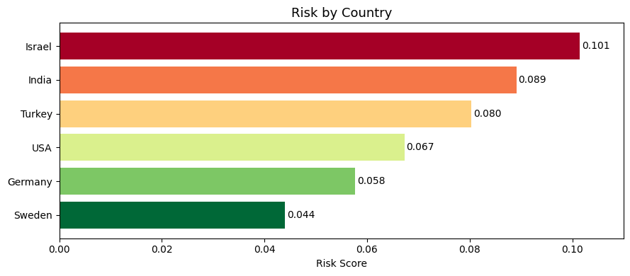

```python
avg_risk_country = df.groupby("country")["risk"].mean().sort_values(ascending=False)

norm = mcolors.Normalize(vmin=avg_risk_country.min(), vmax=avg_risk_country.max())
colors = plt.cm.RdYlGn_r(norm(avg_risk_country.values))

plt.figure(figsize=(9,4))

bars = plt.barh(avg_risk_country.index, avg_risk_country.values, color=colors)

plt.gca().invert_yaxis()
plt.title("Risk by Country", fontsize=13)
plt.xlabel("Risk Score")

plt.bar_label(bars, fmt="%.3f", padding=2)
plt.xlim(0, 0.11)
plt.tight_layout()
plt.show()
```

Bu hücrede her ülke için risk skorlarının zaman içindeki değişimini, renkler risklerini ifade edecek şekilde göstermek istedim. Her grafikte çizgilerin seviyesi ve değişimi, o ülkenin risk profilini gösteriyor.

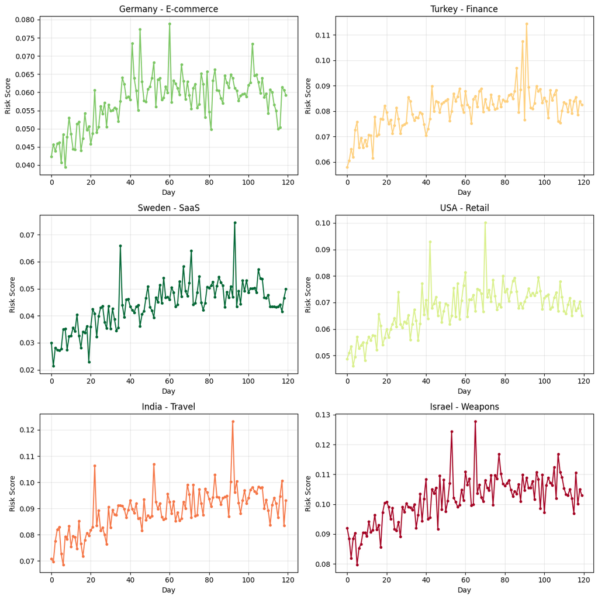

```python
countries = df["country"].unique()
n_countries = len(countries)

avg_risk_country = df.groupby("country")["risk"].mean()

norm = mcolors.Normalize(vmin=avg_risk_country.min(), vmax=avg_risk_country.max())
cmap = plt.cm.RdYlGn_r

fig, axes = plt.subplots(3, 2, figsize=(12, 12))
axes = axes.flatten()

for i, country in enumerate(countries):
    ax = axes[i]
    df_country = df[df["country"] == country]

    color = cmap(norm(avg_risk_country[country]))

    for merchant_id, group in df_country.groupby("merchant_id"):
        ax.plot(group["day"], group["risk"], color=color, marker="o", ms=3, label=merchant_id)

    ax.set_title(f"{country} - {df_country['industry'].iloc[0]}")
    ax.set_xlabel("Day")
    ax.set_ylabel("Risk Score")
    ax.grid(alpha=0.3)

plt.tight_layout()
plt.show()
```

Burada her bir merchant için risk serisine 2. dereceden bir polinom fiti yapıyorum ve anomalilikleri buluyorum; z değeri, işlemin beklenen trendden ne kadar saparak ne kadar olağandışı olduğunu gösteriyor.

```python
fits = []

for merchant, g in df.groupby("merchant_id"):

    coeff    = np.polyfit(g["day"], g["risk"], deg=2)
    fit      = np.poly1d(coeff)(g["day"])
    residual = g["risk"] - fit

    temp = g.copy()

    temp["risk_fit"] = fit
    temp["residual"] = residual
    temp["z"]        = residual / residual.std(ddof=1)
    fits.append(temp)

df_fit = pd.concat(fits, ignore_index=True)
df_fit.head()
```

|  | merchant_id | country | industry | day | tx_count | avg_basket | refund_rate | chargeback_rate | night_ratio | is_campaign | risk | is_anomaly_true | severity_true | risk_fit | residual | z |
| --- | --- | --- | --- | --- | --- | --- | --- | --- | --- | --- | --- | --- | --- | --- | --- | --- |
| 0 | M001 | Germany | E-commerce | 0 | 206 | 75.925259 | 0.010583 | 0.004454 | 0.115244 | 0 | 0.042397 | 0 | 0.0 | 0.042977 | -0.000580 | -0.123026 |
| 1 | M001 | Germany | E-commerce | 1 | 223 | 86.597940 | 0.013862 | 0.005182 | 0.503662 | 0 | 0.045684 | 0 | 0.0 | 0.043497 | 0.002188 | 0.464273 |
| 2 | M001 | Germany | E-commerce | 2 | 216 | 67.654534 | 0.020545 | 0.009389 | 0.221676 | 0 | 0.043841 | 0 | 0.0 | 0.044010 | -0.000169 | -0.035843 |
| 3 | M001 | Germany | E-commerce | 3 | 177 | 65.828957 | 0.035124 | 0.010027 | 0.038839 | 0 | 0.045885 | 0 | 0.0 | 0.044517 | 0.001368 | 0.290433 |
| 4 | M001 | Germany | E-commerce | 4 | 191 | 67.984030 | 0.026411 | 0.004815 | 0.472379 | 0 | 0.046225 | 0 | 0.0 | 0.045016 | 0.001209 | 0.256662 |

Bu hücrede, her ülke için gerçek risk değerlerini, fit edilen trend eğrilerini ve anormal noktaları (yani 2.5 sigma’dan daha yüksek z değerlerine sahip, beklenen trendden belirgin şekilde sapmış günleri) aynı grafikte gösteriyorum. Böylece her panelde hem riskin genel gidişatı hem de trendden saparak olağandışı hale gelen noktalar açıkça görülebiliyor.

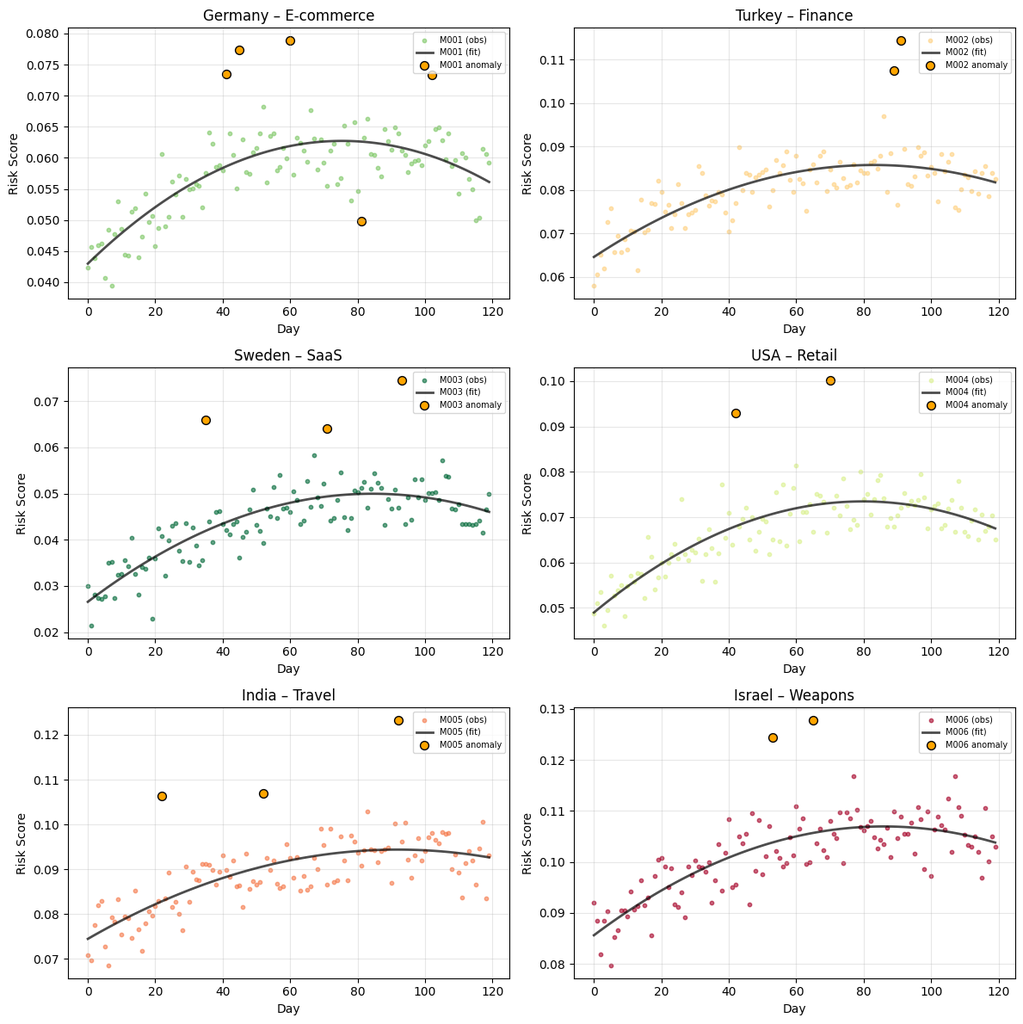

```python
avg_risk_country = df_fit.groupby("country")["risk"].mean()
norm = mcolors.Normalize(vmin=avg_risk_country.min(), vmax=avg_risk_country.max())
cmap = plt.cm.RdYlGn_r

fig, axes = plt.subplots(3, 2, figsize=(12, 12))
axes = axes.flatten()

for i, country in enumerate(countries):
    ax = axes[i]
    df_country = df_fit[df_fit["country"] == country]
    color = cmap(norm(avg_risk_country[country]))


    for merchant_id, group in df_country.groupby("merchant_id"):

        ax.scatter(group["day"], group["risk"], color=color, s=10, alpha=0.6, label=f"{merchant_id} (obs)")
        ax.plot(group["day"], group["risk_fit"], color="black", lw=2, alpha=0.7, label=f"{merchant_id} (fit)")

        anoms = group[np.abs(group["z"]) >= 2.5]

        ax.scatter(anoms["day"], anoms["risk"], color="orange", s=50, edgecolor="k", label=f"{merchant_id} anomaly")

    industries = ", ".join(sorted(df_country["industry"].unique()))
    ax.set_title(f"{country} – {industries}")
    ax.set_xlabel("Day")
    ax.set_ylabel("Risk Score")
    ax.grid(alpha=0.3)
    ax.legend(fontsize=7, loc="best", ncol=1)

plt.tight_layout()
plt.show()
```

Burada da artıkların grafiklerini çiziyorum, aykırı noktalar buradan daha iyi anlaşılabilir.

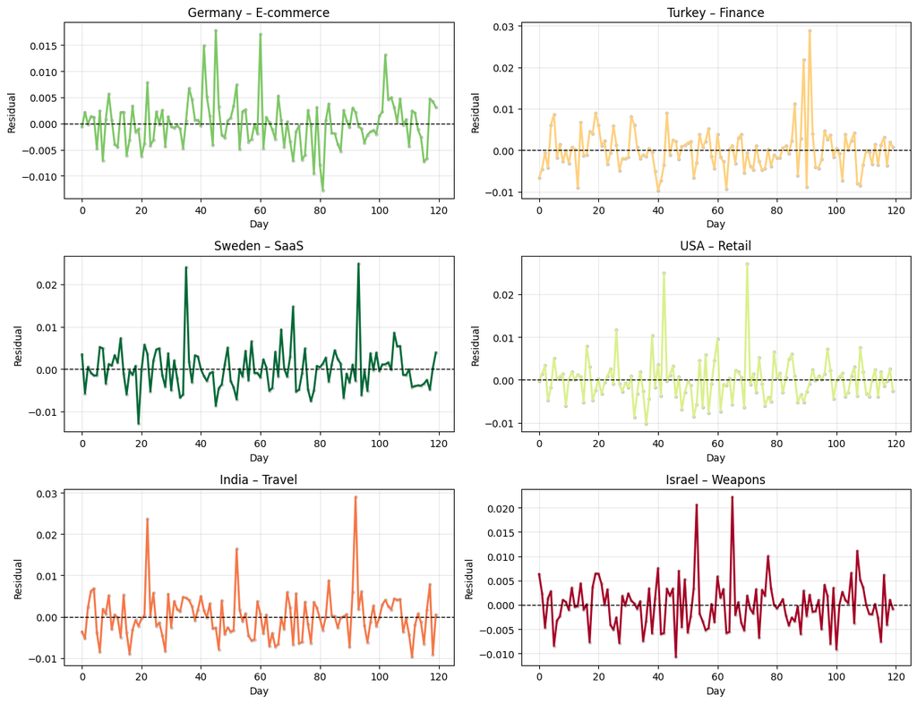

```python
fig, axes = plt.subplots(3, 2, figsize=(13, 10))
axes = axes.ravel()

for i, country in enumerate(countries):
    ax = axes[i]
    g = df_fit[df_fit["country"] == country]
    color = cmap(norm(avg_risk_country[country]))
    inds = ", ".join(sorted(g["industry"].unique()))

    ax.scatter(g["day"], g["residual"], s=8, alpha=0.4, color="0.6")
    mean = g.groupby("day")["residual"].mean()
    ax.plot(mean.index, mean.values, lw=2, color=color)

    ax.axhline(0, color="k", ls="--", lw=1)
    ax.set_title(f"{country} – {inds}")
    ax.set_xlabel("Day")
    ax.set_ylabel("Residual")
    ax.grid(alpha=0.3)

plt.tight_layout()
plt.show()
```

Bu hücre, her ülke × sektör grubu için modelin fit başarımını (`r²_score`) hesaplıyor.  
`r²` değeri, modelin verideki değişkenliği ne kadar iyi açıkladığını gösterir.

Matematiksel olarak:

$$R^2 = 1 - \frac{\sum (y_i - \hat{y}_i)^2}{\sum (y_i - \bar{y})^2}$$

Burada:

- $y_i$ → Gözlenen değerler
- $\hat{y}_i$ → Modelin tahmin ettiği değerler (`risk_fit`)
- $\bar{y}$ → Gözlenen değerlerin ortalaması

**Yorum:**

```python
fit_quality = (
    df_fit.groupby(["country","industry"])
          .apply(lambda g: r2_score(g["risk"], g["risk_fit"]), include_groups=False)
          .reset_index(name="r2_score")
          .sort_values("r2_score", ascending=False)
)

fit_quality
```

|  | country | industry | r2_score |
| --- | --- | --- | --- |
| 5 | USA | Retail | 0.627932 |
| 3 | Sweden | SaaS | 0.623470 |
| 2 | Israel | Weapons | 0.598146 |
| 0 | Germany | E-commerce | 0.564269 |
| 4 | Turkey | Finance | 0.559596 |
| 1 | India | Travel | 0.522714 |

Bu tablo, hangi ülke–sektör kombinasyonlarında fit’in daha iyi çalıştığını gösterir; yüksek $R^2$ değerleri, risk eğrisinin 2. dereceden polinom ile daha iyi temsil edildiği grupları belirtir. Buna göre, en iyi uyum `USA – Retail` (0.628) ve `Sweden – SaaS` (0.623) gruplarında görülür. En düşük uyum ise `India – Travel` (0.523) grubundadır.

Aşağıda ise her ülke için ortalama risk değeri ve anomali oranı hesaplanarak ülkeler risk düzeyine göre sıralanıyor.

```python
summary = (
    df_fit.groupby("country")
    .agg(mean_risk=("risk","mean"),
         anomaly_ratio=("z", lambda x: (abs(x) >= 2.5).mean()))
    .sort_values("mean_risk", ascending=False)
)

summary
```

| country | mean_risk | anomaly_ratio |
| --- | --- | --- |
| Israel | 0.101463 | 0.016667 |
| India | 0.089087 | 0.025000 |
| Turkey | 0.080354 | 0.016667 |
| USA | 0.067264 | 0.016667 |
| Germany | 0.057673 | 0.041667 |
| Sweden | 0.043990 | 0.025000 |

|z| ≥ 2.5 koşulunu sağlayan anomali günlerini görmek istersek aşağıdaki tabloyu oluşturabiliriz.

```python
anom_table = df_fit[np.abs(df_fit["z"]) >= 2.5][["merchant_id","country","industry","day","risk","risk_fit","z"]].sort_values(["country","day"])

anom_table
```

|  | merchant_id | country | industry | day | risk | risk_fit | z |
| --- | --- | --- | --- | --- | --- | --- | --- |
| 41 | M001 | Germany | E-commerce | 41 | 0.073492 | 0.058610 | 3.158417 |
| 45 | M001 | Germany | E-commerce | 45 | 0.077329 | 0.059510 | 3.781675 |
| 60 | M001 | Germany | E-commerce | 60 | 0.078932 | 0.061895 | 3.615805 |
| 81 | M001 | Germany | E-commerce | 81 | 0.049836 | 0.062608 | -2.710726 |
| 102 | M001 | Germany | E-commerce | 102 | 0.073372 | 0.060257 | 2.783586 |
| 502 | M005 | India | Travel | 22 | 0.106440 | 0.082870 | 4.185995 |
| 532 | M005 | India | Travel | 52 | 0.107006 | 0.090641 | 2.906359 |
| 572 | M005 | India | Travel | 92 | 0.123329 | 0.094391 | 5.139369 |
| 653 | M006 | Israel | Weapons | 53 | 0.124376 | 0.103815 | 4.070713 |
| 665 | M006 | Israel | Weapons | 65 | 0.127854 | 0.105684 | 4.389229 |
| 275 | M003 | Sweden | SaaS | 35 | 0.065963 | 0.041950 | 4.609763 |
| 311 | M003 | Sweden | SaaS | 71 | 0.064085 | 0.049378 | 2.823280 |
| 333 | M003 | Sweden | SaaS | 93 | 0.074595 | 0.049727 | 4.774027 |
| 209 | M002 | Turkey | Finance | 89 | 0.107475 | 0.085616 | 4.103467 |
| 211 | M002 | Turkey | Finance | 91 | 0.114429 | 0.085530 | 5.425192 |
| 402 | M004 | USA | Retail | 42 | 0.092856 | 0.067981 | 4.732591 |
| 430 | M004 | USA | Retail | 70 | 0.100219 | 0.073099 | 5.159640 |

Bu hücre, her sektör için anomali skoru olarak `|z|` kullanıp threshold taraması yapıyor; FP (false positive, yanlış alarm) ve FN (false negatif, kaçan gerçek anomali) maliyetlerini (FP=1, FN=4) dikkate alarak toplam maliyeti en aza indiren eşiği seçiyor.

Bunun için `thresholds = 0.5..4.0` aralığında 36 değer deneniyor. Her eşik için `confusion_matrix` ile TP/FP/FN/TN hesaplanıyor; cost = 1×FP + 4×FN. Her eşikte precision ve recall da çıkarılıyor; eğriler `threshold_curves[industry]` içine kaydediliyor. En düşük maliyetli eşik `optimal_threshold` olarak seçilerek; min_cost, precision, recall, fp/fn/tp belirleniyor. Ek olarak ROC AUC ve Average Precision (PR-AUC) (etiket çeşitliliği varsa) ve support (gerçek anomali sayısı) hesaplanıyor.

- `optimal_threshold` yüksekse -> daha katı eşik, genelde FP azalır / FN artar.
- `min_cost` ne kadar düşükse sektör için operasyonel toplam maliyet o kadar iyidir.
- `precision` alarm doğruluğunu, `recall` yakalanan gerçek anomali oranını; ROC AUC genel ayırt edebilirliği, avg_precision ise dengesiz sınıflarda performansı özetler.

```python
FP_COST = 1.0
FN_COST = 4.0

threshold_curves = {}
rows = []

for industry, group in df_fit.groupby("industry"):

    y_true = group["is_anomaly_true"].values
    y_score = group["z"].abs().values

    thresholds = np.linspace(0.5, 4.0, 36)

    curve = []
    for thr in thresholds:

        preds          = (y_score >= thr).astype(int)
        tn, fp, fn, tp = confusion_matrix(y_true, preds, labels=[0, 1]).ravel()
        cost           = FP_COST * fp + FN_COST * fn
        precision = tp / (tp + fp) if (tp + fp) else 0.0
        recall    = tp / (tp + fn) if (tp + fn) else 0.0

        curve.append({"threshold": thr,
                      "cost": cost,
                      "precision": precision,
                      "recall": recall,
                      "fp": fp,
                      "fn": fn,
                      "tp": tp})

    curve_df = pd.DataFrame(curve)
    threshold_curves[industry] = curve_df

    best = curve_df.loc[curve_df["cost"].idxmin()]

    rows.append({
        "industry"          : industry,
        "optimal_threshold" : best["threshold"],
        "min_cost"          : best["cost"],
        "precision"         : best["precision"],
        "recall"            : best["recall"],
        "fp"                : int(best["fp"]),
        "fn"                : int(best["fn"]),
        "tp"                : int(best["tp"]),
        "roc_auc"           : roc_auc_score(y_true, y_score),
        "avg_precision"     : average_precision_score(y_true, y_score),
        "support"           : int(y_true.sum())
    })

cost_summary = pd.DataFrame(rows).sort_values("optimal_threshold")
cost_summary
```

|  | industry | optimal_threshold | min_cost | precision | recall | fp | fn | tp | roc_auc | avg_precision | support |
| --- | --- | --- | --- | --- | --- | --- | --- | --- | --- | --- | --- |
| 4 | Travel | 1.8 | 0.0 | 1.0 | 1.0 | 0 | 0 | 3 | 1.000000 | 1.000000 | 3 |
| 1 | Finance | 1.9 | 0.0 | 1.0 | 1.0 | 0 | 0 | 3 | 1.000000 | 1.000000 | 3 |
| 5 | Weapons | 1.9 | 2.0 | 0.6 | 1.0 | 2 | 0 | 3 | 0.994302 | 0.866667 | 3 |
| 2 | Retail | 1.9 | 2.0 | 0.6 | 1.0 | 2 | 0 | 3 | 0.997151 | 0.916667 | 3 |
| 3 | SaaS | 2.5 | 0.0 | 1.0 | 1.0 | 0 | 0 | 3 | 1.000000 | 1.000000 | 3 |
| 0 | E-commerce | 2.8 | 0.0 | 1.0 | 1.0 | 0 | 0 | 3 | 1.000000 | 1.000000 | 3 |

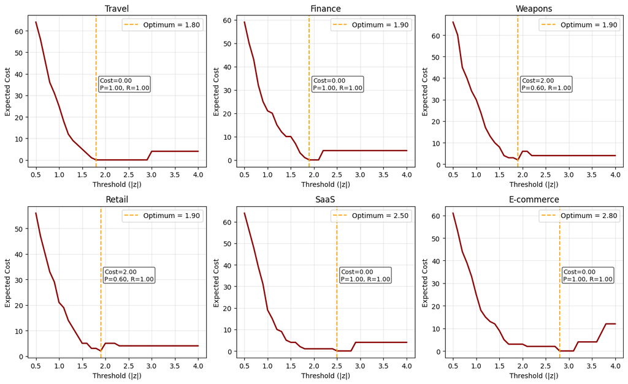

```python
fig, axes = plt.subplots(2, 3, figsize=(13, 8))
axes = axes.flatten()

for i, row in enumerate(cost_summary.itertuples()):
    ax = axes[i]
    curve_df = threshold_curves[row.industry]

    ax.plot(curve_df["threshold"], curve_df["cost"], color="darkred", lw=2)
    ax.axvline(row.optimal_threshold, color="orange", linestyle="--",
               label=f"Optimum = {row.optimal_threshold:.2f}")

    ax.set_title(f"{row.industry}")
    ax.set_xlabel("Threshold (|z|)")
    ax.set_ylabel("Expected Cost")
    ax.grid(alpha=0.3)
    ax.legend(loc="best")

    ymin, ymax = curve_df["cost"].min(), curve_df["cost"].max()
    xpos = row.optimal_threshold + 0.08
    ypos = ymin + 0.5 * (ymax - ymin)

    ax.text(xpos, ypos,
            f"Cost={row.min_cost:.2f}\nP={row.precision:.2f}, R={row.recall:.2f}",
            ha="left", va="bottom", fontsize=9,
            bbox=dict(boxstyle="round,pad=0.2", facecolor="white", alpha=0.7))

plt.tight_layout()
plt.show()
```

Her grafikte, belirli bir sektör için `|z|` eşiği arttıkça beklenen toplam maliyetin nasıl değiştiği gösteriliyor.  
Kırmızı çizgi, yanlış pozitif (FP) ve yanlış negatif (FN) hatalarının maliyetleriyle hesaplanan Cost = FP_COST x FP + FN_COST x FN fonksiyonunu temsil ediyor.  
Turuncu kesikli çizgi, maliyeti minimize eden optimum eşiği (`optimal_threshold`) gösteriyor ve legend`da bu noktadaki Cost, Precision (P) ve Recall (R) değerleri verilmiştir.

Genel olarak:

- Eşik yükseldikçe yanlış alarmlar azalıyor fakat kaçan anomaliler artıyor.
- Eğrinin taban noktası, FP ve FN dengesini sağlayan en uygun karar eşiğini temsil ediyor.

Grafiklere göre:

- Travel, Finance ve SaaS sektörlerinde düşük eşiğe rağmen hatasız (Cost=0, P=1.0, R=1.0) sınıflama elde edilmiş.
- Weapons ve Retail sektörlerinde optimum eşik 1.9 olup düşük ama sıfırdan büyük maliyet (Cost=2) oluşmuş.
- E-commerce sektörü, daha yüksek optimum eşiğe (2.8) sahip; bu da modelin anomalileri tanımak için daha katı bir `|z|` eşiğine ihtiyaç duyduğunu gösteriyor.

```python
threshold_map = cost_summary.set_index("industry")["optimal_threshold"]

df_fit["threshold_industry"] = df_fit["industry"].map(threshold_map)
df_fit["detected_anomaly"] = (df_fit["z"].abs() >= df_fit["threshold_industry"])

cols = ["tx_count", "refund_rate", "chargeback_rate", "night_ratio", "avg_basket", "risk"]

summary_compare = []

for ind, group in df_fit.groupby("industry"):
    normal                   = group[~group["detected_anomaly"]][cols].mean()
    anomaly                  = group[group["detected_anomaly"]][cols].mean()
    diff                     = (anomaly - normal) / normal * 100
    diff["industry"]         = ind
    diff["support_detected"] = group["detected_anomaly"].sum()
    diff["support_true"]     = group["is_anomaly_true"].sum()

    summary_compare.append(diff)

impact_df = (pd.DataFrame(summary_compare).set_index("industry").round(2))

impact_df
```

| industry | tx_count | refund_rate | chargeback_rate | night_ratio | avg_basket | risk | support_detected | support_true |
| --- | --- | --- | --- | --- | --- | --- | --- | --- |
| E-commerce | 17.85 | 33.17 | 250.84 | 45.16 | 36.98 | 33.92 | 3 | 3 |
| Finance | 22.14 | 117.07 | 74.88 | -24.85 | 43.99 | 33.35 | 3 | 3 |
| Retail | 11.03 | 33.83 | 199.91 | 77.74 | 2.95 | 19.94 | 5 | 3 |
| SaaS | 20.23 | 134.92 | 412.82 | 31.65 | 19.12 | 57.29 | 3 | 3 |
| Travel | 22.09 | 225.82 | 176.47 | -6.22 | 31.35 | 26.86 | 3 | 3 |
| Weapons | 13.08 | 65.29 | 96.70 | -11.90 | 12.71 | 14.49 | 5 | 3 |

Yukardaki hücrede her sektör için maliyet-duyarlı en iyi eşiği (|z|) uygulayıp satırları anomali / normal olarak ayırdık; ardından seçili metriklerde (tx_count, refund_rate, chargeback_rate, night_ratio, avg_basket, risk) anomali günlerinin ortalamasını normal günlere göre % fark olarak hesapladım. Ayrıca support_detected (tespit edilen anomali sayısı) ve support_true (gerçek anomali sayısı) ile tespit kalitesini özetledim.

Özetle, bu tablo anomalilerin hangi metrikleri ne yönde etkilediğini yüzdesel olarak açıkça gösteriyor ve tespit kalitesine dair hızlı bir sağlık kontrolü sağlıyor.

### Sonuç

Bu notebook’ta, sentetik bir veri kümesi üzerinde ülke ve sektör bazlı risk analizi yaparak uçtan uca bir anomali tespiti akışı kurdum: veri üretimi -> trend fit -> z-skoru ile sapma -> maliyet-duyarlı eşik seçimi (FP/FN) -> etki analizi (anomali/normal gün karşılaştırması). Eşikler sektör özelinde optimize edilerek hem yanlış alarm yükü azaltıldı hem de kaçan anomali maliyeti kontrol altına alındı. Görselleştirmeler, risk seviyesinin zaman içindeki davranışını ve tespit edilen anomalilerin iş metriklerine etkisini net biçimde ortaya koydu.

**Bulgular:**

- Anomalilerde refund/chargeback oranlarının belirgin artışı, tespitlerin işsel anlamlılığını destekliyor.
- Ülke–sektör bazında risk seviyesi ile anomali oranı her zaman paralel değil; bazı profiller yüksek ama stabil risk sergilerken, bazıları düşük risk fakat oynak görünüm sunuyor.
- Maliyet eğrileri, pratik operasyon için optimum alarm eşiğini somut biçimde belirlemeyi sağlıyor.

**Netice:** Bu çalışma, z-skor tabanlı ve maliyet-duyarlı bir yaklaşımın açıklanabilir, ayarlanabilir ve operasyonel bir anomali tespit katmanı olarak nasıl kurgulanabileceğini gösterir.